# Human Activity Recognition by Wearable Accelometer

Kisun

Dec-21-2014

### Synopsis

This document is related with analyzing human activities by using data which was collected from wearable acceometers. The activities which are going to be analyzed are 5 types, {Sitting, Sitting down, Standing, Standing up, Walking}. Those are labeled as A..E.

All analyzing process are done with helping R Caret package, and Random Forest algorithm is used to predict outcomes.

### Load Caret

All processes are done under the assumption `caret` and `corrplot` packages are already installed.

```r
library(caret)
```

```r
library(corrplot)
```

### Data Processing

Data Processing steps are begining with pre-condition that traing & tesing files are exist in local working directory.

```r
training <- read.csv("pml-training.csv", stringsAsFactors = FALSE, na.strings = c("NA", ""))
testing <- read.csv("pml-testing.csv", stringsAsFactors = FALSE, na.strings = c("NA", ""))
```

Many values are missing, some values are specified as “NA”, but mostly as “”. For better clarity `na.strings = c("NA", "")` option is used.

There are 160 columns in the original training data, but many columns are entirely missing. Entirly missing columns are usessless to make prediction, so those are needed to be wiped out. Before clearing NA values in two data frames, we need to make sure whether entirely NA values have same column names or not.

```r
findNAClmns <- function(df) {
  naClmns <- vector()
  for (clmnName in colnames(df)) {
    if(mean(is.na(df[,clmnName])) != 0) naClmns <- c(naClmns, clmnName)
  }
  naClmns
}

setdiff(findNAClmns(training), findNAClmns(testing))
```

```
## character(0)
```

```r
setdiff(findNAClmns(testing), findNAClmns(training))
```

```
## character(0)
```

Both of two dataFrames have entirely NA values with same column names in common, so it is much better if we clean out those columns.

```r
training <- training[, colSums(is.na(training)) == 0]
testing <- testing[, colSums(is.na(testing)) == 0]
```

```r
colnames(training)[1:7]
```

```
## [1] "X"                    "user_name"            "raw_timestamp_part_1"
## [4] "raw_timestamp_part_2" "cvtd_timestamp"       "new_window"
## [7] "num_window"
```

```r
colnames(testing)[1:7]
```

```
## [1] "X"                    "user_name"            "raw_timestamp_part_1"
## [4] "raw_timestamp_part_2" "cvtd_timestamp"       "new_window"
## [7] "num_window"
```

There aren’t NA values in columns from 1 to 7 (“X”, “user_name”, “raw_timestamp_part_1”, “raw_timestamp_part_2”, “cvtd_timestamp”, “new_window”, “num_window”). But these are not useful in this analyzing.

We can filter out useless columns.

```r
training <- training[, -c(1:7)]
testing <- testing[, -c(1:7)]
```

After filtering out, we get 53 columns.

Cause we loaded training data with`stringsAsFactors = FALSE`, we need to set training$classe data as factor type (By the way there is no classe column in testing data).

```r
training$classe <- as.factor(training$classe)
```

### preprocess with PCA

When we plot a correlation matrix of the traing data, we can find out there are not a few columns are having higher correlation values each others.

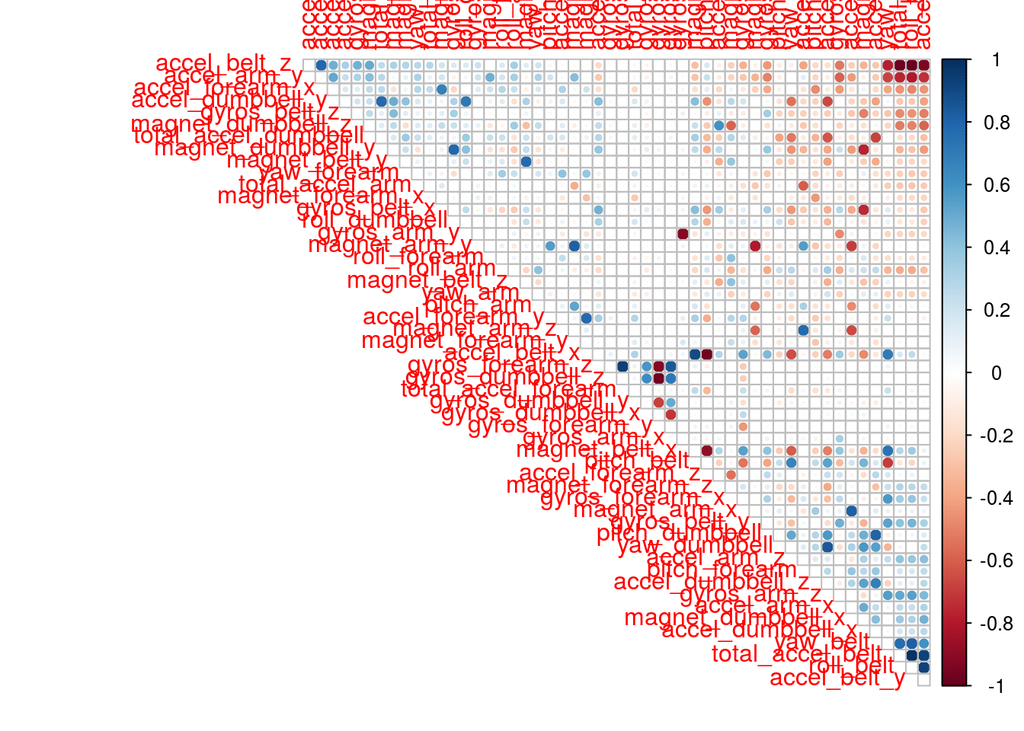

```r
corrMat <- cor(training[, -53])
diag(corrMat) <- 0
corrplot(corrMat, order="FPC", type="upper")
```

In this case, using PCA is a good idea to make a compact data set without losing data characteristics.

```r
set.seed(12345)
sampleIndex <- createDataPartition(y=training$classe, p = 0.7, list = FALSE)
training <- training[sampleIndex,]
validation <- training[-sampleIndex,]
```

Then we apply PCA method.

```r
preProc <- preProcess(training[, -53], method = "pca", thresh = 0.99)
compactTraining <- predict(preProc, training[, -53])

dim(compactTraining)[2]
```

```
## [1] 36
```

### Training and Cross-Validation

Even though we use PCA as a pre-process function and the sampled training data, but the training data is so large, so below codes are taking so long time to process.

In oder to use cross validation method, this analyze uses 4-fold cross validation method by specifying `trControl’. The reason why use 4-fold cross validation is to let the fitting computarion be more quickly.

```r
modelFit <- train(training$classe ~.,
                data = compactTraining,
                method="rf",
                trControl = trainControl(method = "cv", number = 4),
                prox = TRUE,
                allowParallel = TRUE)
modelFit
```

```
## Random Forest
##
## 13737 samples
##    35 predictors
##     5 classes: 'A', 'B', 'C', 'D', 'E'
##
## No pre-processing
## Resampling: Cross-Validated (4 fold)
##
## Summary of sample sizes: 10301, 10304, 10303, 10303
##
## Resampling results across tuning parameters:
##
##   mtry  Accuracy  Kappa  Accuracy SD  Kappa SD
##    2    0.972     0.964  0.00392      0.00497
##   19    0.965     0.956  0.00186      0.00235
##   36    0.957     0.946  0.00220      0.00279
##
## Accuracy was used to select the optimal model using  the largest value.
## The final value used for the model was mtry = 2.
```

After we getting a model to predict with, we need to check its accuracy by validating with validation data.

```r
compactValidation <- predict(preProc, validation[, -53])
confusionMatrix(predict(modelFit, newdata = compactValidation), validation$classe)
```

```
## Confusion Matrix and Statistics
##
##           Reference
## Prediction    A    B    C    D    E
##          A 1161    0    0    0    0
##          B    0  802    0    0    0
##          C    0    0  719    0    0
##          D    0    0    0  706    0
##          E    0    0    0    0  722
##
## Overall Statistics
##
##                Accuracy : 1
##                  95% CI : (0.9991, 1)
##     No Information Rate : 0.2825
##     P-Value [Acc > NIR] : < 2.2e-16
##
##                   Kappa : 1
##  Mcnemar's Test P-Value : NA
##
## Statistics by Class:
##
##                      Class: A Class: B Class: C Class: D Class: E
## Sensitivity            1.0000   1.0000   1.0000   1.0000   1.0000
## Specificity            1.0000   1.0000   1.0000   1.0000   1.0000
## Pos Pred Value         1.0000   1.0000   1.0000   1.0000   1.0000
## Neg Pred Value         1.0000   1.0000   1.0000   1.0000   1.0000
## Prevalence             0.2825   0.1951   0.1749   0.1718   0.1757
## Detection Rate         0.2825   0.1951   0.1749   0.1718   0.1757
## Detection Prevalence   0.2825   0.1951   0.1749   0.1718   0.1757
## Balanced Accuracy      1.0000   1.0000   1.0000   1.0000   1.0000
```

### Prediction

We apply PCA to the test data, as we do to the training data. Then We run `predcit` method to get predicted results.

```r
compactTesting <- predict(preProc, testing[, -53])
predicted <- predict(modelFit, compactTesting)
print(predicted)
```

```
##  [1] B A B A A E D B A A B C B A E E A B B B
## Levels: A B C D E
```